# "WS05_solution"

# Workshop 5: Exploring Numerical Summing Schemes

[figure not shown]

[figure not shown]

*[CEGM1000 MUDE](http://mude.citg.tudelft.nl/): Week 1.5, Wednesday, Oct 4, 2023.*

## Overview

Numerical integration techniques are used in cases where we are beginning from a physics-based model defined with an integral relation. It is an essential tool in computational engineering due to the ability to approximate complex integrals that sometimes don't have closed-form solutions. These numerical techniques allow us to analyze and predict the behaviour of complex systems in a computationally efficient manner that computers are well suited to solving. In particular, these numerical integration techniques allow us to understand and model physical phenomena and are the initial step to more involved finite difference and finite volume models that you will see later in MUDE.

In this example, we will demonstrate numerical integration techniques by starting with a simple expression that can be solved analytically by hand to compute the exact solution, and then employ some numerical techniques to solve as a comparison with a few numerical methods.

Let's begin by starting with an expression that we can analytically solve to begin our comparison. Here's the starting function:

$$f(x)=\int_0^{4\pi} \left(10
\sin(x)+4x\right)\mathrm{d}x$$

**NOTE:** you may notice that the notation of some methods is slightly different than that in the book. That's ok - just convince yourself that the indices and $x$ values work out the way they should. It is especially important to make sure you recognize that there may be a difference between the mathematical notation and the Python index.

```python
import numpy as np
import matplotlib.pyplot as plt
```

**Task 1:** Solve the above equation by hand and enter the exact solution below! This will be used later as a comparison to the approximations.

```python
# Calculate the exact integral
## YOUR SOLUTION HERE
exact_integral = -10*np.cos(4*np.pi)+2*(4*np.pi)**2-(10*-np.cos(0))
print(f"Exact solution: {exact_integral: 0.3f}")
```

```
Exact solution:  315.827
```

```python
import sympy as sp

x = sp.symbols('x')
int = 10*sp.sin(x)+4*x
a=0
b=4*sp.pi

exact_soln = sp.integrate(int, (x,a,b))
display(exact_soln)
```

```
32*pi**2
```

**Defining the function, interval, and displaying the plot**

In the code below, we are defining the initial integral as a `function`. This will allow us to call the integral depending on what we want to accomplish. Be that to plot a nice curve with `high_res_values` or pass the correct number of subintervals with `x_values` (that one is coming up!).

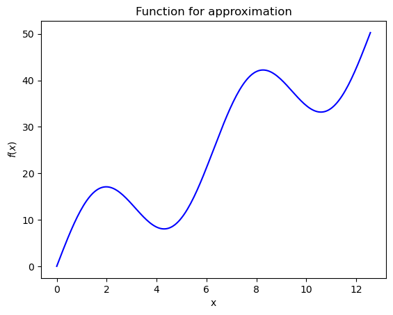

```python
# Define the integral function
def func(x):
    return 10*np.sin(x)+4*x

# Define the integration interval [a, b]
# YOUR CODE HERE
# a = ??
# b = ??
a = 0
b = 4*np.pi

# To plot the a smooth graph of the function
high_res_values = np.linspace(a, b, 200)

plt.plot(high_res_values, [func(x) for x in high_res_values], 'b', label='Cross-Sectional Area Function');
plt.title('Function for approximation')
plt.xlabel('x')
plt.ylabel('$f(x)$');
```

**Setting up**

In the next cell, we define a few terms that we will use throughout the notebook.

The `n` value defines how many subintervals that we divide our function into during the approximation. For our case, initially, let's go with $10$ divisions.

We will also calculate the width of each subinterval below. The expression for the width of the subinterval is

$$\Delta x=\frac{b-a}{n}$$

```python
# Define the number of subintervals (n)
n = 10

# Compute the width of each subinterval
#YOUR CODE HERE
#dx = ??
dx = (b - a) / n

# Create an array of sample points within the interval [a, b]
x_values = np.linspace(a, b, n+1)
```

**The Left Riemann Sum**

This method approximates an integral by calculating and summing the area of rectangles with left endpoints defined by the function. Mathematically, we can represent this as

$$\sum_{i=0}^{n-1} f(x_i)\Delta x$$

Take note of how simply this can be implemented in code!

```
Left Riemann Sum:  2.842e+02
```

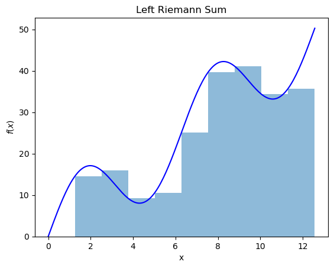

```python
left_riemann_sum = sum([func(x_values[i]) for i in range(n)]) * dx

# Left Riemann sum
plt.plot(high_res_values, [func(x) for x in high_res_values], 'b')
plt.bar(x_values[:-1],
        [func(x_values[i]) for i in range(n)],
        width=dx, alpha=0.5, align='edge')
plt.title('Left Riemann Sum')
plt.xlabel('x')
plt.ylabel('$f(x)$');
print(f"Left Riemann Sum: {left_riemann_sum: 0.3e}")
```

**The Right Riemann Method**

Similar to the left Riemann sum, this method is also algebraically simple to implement, and can be better suited to some situations, depending on the type of function you are trying to approximate. In this case, the subintervals are defined using the right-hand endpoints from the function and is represented by

$$\sum_{i=1}^n f(x_i)\Delta x$$

**Task 2:** Complete the code cell below by adding the appropriate evaluations of $f(x)$ below. Use the Left Riemann code above as a guide.

[output not shown]

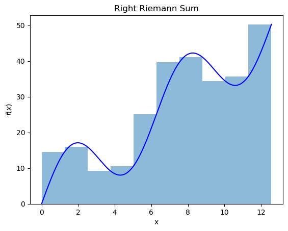

```python
right_riemann_sum = sum([func(x_values[i]) for i in range(n)]) * dx

print(f"Right Riemann Sum: {right_riemann_sum: 0.3e}")

# Right Riemann sum
plt.plot(high_res_values, [func(x) for x in high_res_values], 'b')
plt.bar(x_values[1:],
        [func(x_values[i+1]) for i in range(n)],
        width=-dx, alpha=0.5, align='edge')
plt.title('Right Riemann Sum')
plt.xlabel('x')
plt.ylabel('$f(x)$');
```

**Midpoint Method Approximation**

The midpoint method approximates the integral taking the midpoint of the rectangle and splitting the width of the rectangle at this point.

$$\sum_{i=1}^n f(x_m)\Delta x \quad
\mathrm{where }\quad x_m=\left(i-\frac{1}{2}\right)\Delta x$$

In terms of implementing this in code, there are multiple methods that can be employed. Here is one method:

**Task 3:** Complete the code cell below by adding the appropriate evaluations of $f(x)$ for the midpoint sum below.

```
Midpoint Sum:  3.158e+02
```

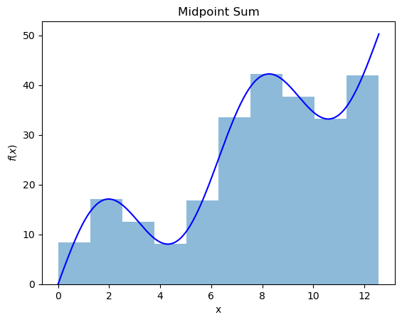

```python
midpoint_sum = sum([func((x_values[i] + x_values[i+1]) / 2) for i in range(n)]) * dx

print(f"Midpoint Sum: {midpoint_sum: 0.3e}")

# Midpoint sum
plt.plot(high_res_values, [func(x) for x in high_res_values], 'b')
plt.bar([(x_values[i] + x_values[i+1]) / 2 for i in range(n)],
        [func((x_values[i] + x_values[i+1]) / 2) for i in range(n)],
        width=dx, alpha=0.5)
plt.title('Midpoint Sum')
plt.xlabel('x')
plt.ylabel('$f(x)$');
```

**Trapezoidal Rule**

This method is slightly more algebraic and involves forming trapezoidal subintervals under the curve to determine the area. One key difference is that it considers both a left and right endpoints over each interval.

$$\sum_{i=1}^n\frac{f(x_{i-1})+f(x_i)}{2}\Delta x
\quad \mathrm{where }\quad x_i=i\Delta x$$

**Task 4:** Complete the following code to implement the trapezoidal rule for the sum. Here, you will have to be able to sort the indices carefully. You will get an error with the `plt.fill_between` function, but use your debugging skills and the traceback to sort out how to fix the arguments.

```
Trapezoidal Sum:  3.158e+02
```

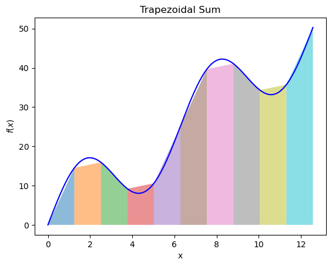

```python
trapezoidal_sum = sum([(func(x_values[i]) + func(x_values[i+1])) / 2 for i in range(n)]) * dx

print(f"Trapezoidal Sum: {trapezoidal_sum: 0.3e}")

# Trapezoidal sum
plt.plot(high_res_values, [func(x) for x in high_res_values], 'b')
for i in range(n):
    plt.fill_between([x_values[i], x_values[i+1]],
                     [func(x_values[i]), func(x_values[i+1])],
                     alpha=0.5)
plt.title('Trapezoidal Sum')
plt.xlabel('x')
plt.ylabel('$f(x)$');
```

**Absolute errors in integral**

```python
# Calculate absolute errors
left_riemann_error = abs(exact_integral - left_riemann_sum)
right_riemann_error = abs(exact_integral - right_riemann_sum)
midpoint_error = abs(exact_integral - midpoint_sum)
trapezoidal_error = abs(exact_integral - trapezoidal_sum)

# Print the results
print(f"Left Riemann Error: {left_riemann_error: 0.3e}")
print(f"Right Riemann Error: {right_riemann_error: 0.3e}")
print(f"Midpoint Error: {midpoint_error: 0.3e}")
print(f"Trapezoidal Error: {trapezoidal_error: 0.3e}")
```

```
Left Riemann Error:  3.158e+01
Right Riemann Error:  3.158e+01
Midpoint Error:  5.684e-14
Trapezoidal Error:  0.000e+00
```

**Simpson's Rule**

Simpson's rule is a method that uses a quadratic approximation over an interval that allows the top bound of the area 'rectangle' to be defined by a polynomial. In general, it can be a better approximation for curved, but mathematically smooth functions. It also has the requirement that subintervals must be an even number, so this is something to be aware of when using it in practise. As a sum, it is defined as

$$\int^{b}_{a}f(x)\mathrm{d}x\approx
\sum_{i=1}^{n/2}\frac{1}{3}(f(x_{2i-2})+4f(x_{2i-1})+f(x_{2i}))\Delta
x$$

where $n$ must be an *even integer*.

**NOTE:** Original student file mistakenly used `i=0` in the expression above.

**Task 5** Now it's **your** turn! Try to take what you have seen in the other numerical implementation codes and implement Simpson's Rule for the same integral! Use the start of the code below to help guide your implementation. You may find it useful to know that you can define a `` `for` `` loop such that it skips over the middle value, as in `` `for i in range(0,n,2)` ``

One "trick" here was recognizing the indexes and their meaning (ours are generally giving the integration interval) and how they differ between the mathematical formulation and the Python code (shifted by 1). Also important to recognize that we need to take the interval index and relate it to the $x_i$ points and `x_values`. With Simpson, you should always check the ranges and indices by printing values to make sure they make sense. Finally, the solution below adds a plot for Simpson to illustrate that even though it is derived from a parabolic fit, you can interpret it as an equivalent rectangle (plotted). The value of the fraction in the integration line and plotting line is different; the $1/6$ in the plot comes from the Simpsoninterval being over $2 \Delta x$, which is left out of the rectangle height calculation.

```
Simpson's Rule Integral:  3.158e+02
Simpson's Rule Absolute Error:  0.000e+00
```

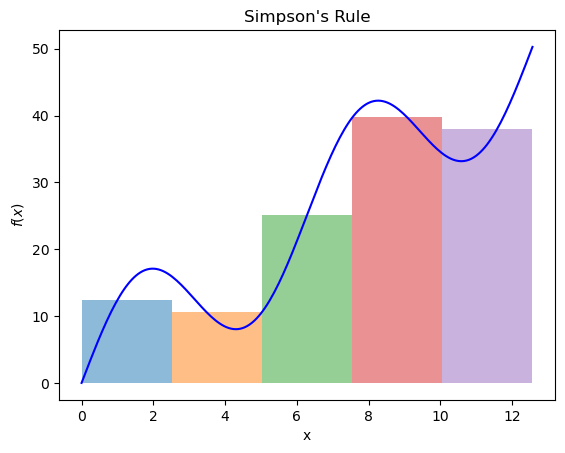

```python
# Define Simpson's Rule here
# simpson_integral= ??
simpson_integral = \
    sum(1/3*(func(x_values[2*i-2]) + 4*func(x_values[2*i-1]) + func(x_values[2*i]))*dx
    for i in range(1, n//2+1))

# Calculate the absolute error
simpson_error = abs(exact_integral - simpson_integral)

# Print the result and error
print(f"Simpson's Rule Integral: {simpson_integral: 0.3e}")
print(f"Simpson's Rule Absolute Error: {simpson_error: 0.3e}")

plt.plot(high_res_values, [func(x) for x in high_res_values], 'b')

for i in range(1, n//2+1):
    plt.fill_between([x_values[2*i-2], x_values[2*i]],
                     np.array([1, 1])*1/6*(func(x_values[2*i-2]) + 4*func(x_values[2*i-1]) + func(x_values[2*i])),
                     alpha=0.5)
plt.title('Simpson\'s Rule')
plt.xlabel('x')
plt.ylabel('$f(x)$');
```

**Task 6:** All of the approximations in this exercise were completed with a relatively small number of subintervals ($n=10$) at the beginning of the notebook. It is worth your time to look at how each of these approximations improve in accuracy as the number of subintervals increase. Try - increasing this number and take note of how much longer it takes to run the notebook and get the results as well. - decreasing the number of intervals, take note of the resulting plots and results. You can also feel free to play with other expressions! Change the `func(x)` expression near the top of the notebook and see how the different numeric schemes behave for other functions. It's useful to see how these integral technniques handle different functions. Enjoy!

**End of notebook.**

[figure not shown]

[figure not shown]

© Copyright 2023 [MUDE Teaching Team](https://studiegids.tudelft.nl/a101_displayCourse.do?course_id=65595) TU Delft. This work is licensed under a [Creative Commons Attribution-NonCommercial-ShareAlike 4.0 International License](http://creativecommons.org/licenses/by-nc-sa/4.0/).